# Cyclistic Case Study

Markise Williams

2023-01-29

### Introduction

For the Google Data Analytic Certificate, my analysis will be done on the Cyclistic bike share data. For the case study, I will provide data analysis as a Junior Data Analyst for the marketing team at Cyclistic, a fictional bike-share company in Chicago. I will answer key business questions while following all six steps of the data analytic process.

### The Scenario

The Director of marketing of Cyclistic, Lily Moreno, believes that the next step to company success is to maximize the number of annual memberships. So the goal of the marketing analyst team is to understand how causal riders and annual riders differ in their use of the Cyclistic bikes. From these insights, the analytics team could be able to design a new marketing strategy to incentivize casual riders to become annual members.

Three questions will be answered.

1. How do annual members and casual riders use Cyclistic bikes differently?
2. Why would casual riders buy Cyclistic annual memberships?
3. How can Cyclistic use digital media to influence casual riders to become member?

I have been assigned by Moreno the first question.

### Ask Phase

*Business Task Statement

Customer retention and satisfaction has been an ongoing business task. Cyclistic has developed one of the most successful and affordable bike share businesses in Chicago. All with the purpose of providing reliable transportation to their customers. For example, Cyclistic sets itself apart by providing a large variety of bikes ranging from reclining bikes, hand tricycles, to cargo bikes, making bike-share more inclusive to people with disabilities and riders who can’t use a standard two-wheeled bike. It is best to communicate this general awareness and appeal to a broad range of consumers by understanding your customer. By knowing how to attract new customers who will be users of Cyclistic. Even down to convincing your casual rider to become Cyclistic members.

*My key stakeholders are:

1- Lily Moreno: The Director of Marketing will be the first stakeholder delivered to.

2- The Executive team, who has the power to approve our recommendations, will be delivered to.

### Prepare Phase

Data Source: Past 12 months of bike share data 01/01/2022 to 31/12/2022 was extracted as 12 zipped .csv [files](https://divvy-tripdata.s3.amazonws.com/index.html). The data is made available and licensed by Motivate International Inc under this [license](https://ride.divvybikes.com/data-license-agreement).

Data Organization & Description:

File naming convention: YYYY_MM

File Type: csv format

File Content: Each csv file consist of 13 columns which contain information related to ride id, rider type, ride start and end time, start and end location, and various others. Number of rows ranged to around 531k from different excel files

Data credibility:

Data set is reliable and accurate given the time frame of last 12 months.

Data set is original and a first arty information

Data set contains all information needed to answer the question.

The data set is cited and vetted by the Chicago Department of Transportation.

Original files are backed up in a separate folder.

Following data limitation: As riders’ personal identifiable information is hidden, thus will not be able to connect pass purchases to credit cards numbers to determine if casual riders live in the Cyclistic service area or if they have purchased multiple single passes.

### Process Phase

R Studio was the method of analysis The 12 data sets were too big for Google Sheets and Big Query. Google Sheets can only handle around 1 million rows and Big Query cant because of file sizes. R Studio was the more viable approach.

### Analyze Phase

12 packages were installed fro reading, cleaning, organizing, and analyzing the data: tidyverse, janitor, skimr, hablar, readxl, data.table, chron, readr, lubridate, magrittr, DescTools, metR.

```r
library(tidyverse)
library(janitor)
library(skimr)
library(hablar)
library(readxl)
library(data.table)
library(chron)
library(readr)
library(lubridate)
library(magrittr)
library(DescTools)
library(metR)
```

### Importing data

Cyclist data from 01/2022 to 12/2022 is imported and read as .cvs files.

```r
data_01 <- read_csv("cs2022_01.csv")
data_02 <- read_csv("cs2022_02.csv")
data_03 <- read_csv("cs2022_03.csv")
data_04 <- read_csv("cs2022_04.csv")
data_05 <- read_csv("cs2022_05.csv")
data_06 <- read_csv("cs2022_06.csv")
data_07 <- read_csv("cs2022_07.csv")
data_08 <- read_csv("cs2022_08.csv")
data_09 <- read_csv("cs2022_09.csv")
data_10 <- read_csv("cs2022_10.csv")
data_11 <- read_csv("cs2022_11.csv")
data_12 <- read_csv("cs2022_12.csv")
```

Compare the names of each column so that each match.

```r
colnames(data_01)
colnames(data_02)
colnames(data_03)
colnames(data_04)
colnames(data_05)
colnames(data_06)
colnames(data_07)
colnames(data_08)
colnames(data_09)
colnames(data_10)
colnames(data_11)
colnames(data_12)
```

All 12 data sets are combined to form a data frame of 5595028 observations.

```r
alltrips <- rbind(data_01,data_02,data_03,data_04,data_05,data_06,data_07,data_08,data_09,data_10,data_11,data_12)
```

### Clean up and organize the data for analysis

Inspect the new table that has been created.

```r
colnames(alltrips) #List of column names
dim(alltrips) #Dimensions of the data frame
head(alltrips) #See the first 6 rows of the data frame
str(alltrips) #see the list of columns and data types (numeric, charter, etc)
```

The columns that list the date, month, day, year, and day_of_week of each ride are added. days of the week are assigned the numbers 1:Monday, 2:Tuesday, etc. This will allow the aggregation of the data by each day, month or day_of_week.

```r
alltrips$date <- as.Date(alltrips$started_at)
alltrips$month <- format(as.Date(alltrips$date), "%m")
alltrips$day <- format(as.Date(alltrips$date), "%d")
alltrips$year <- format(as.Date(alltrips$date), "%Y")
alltrips$day_of_week <- format(as.Date(alltrips$date), "%u")
```

Add a “ride_length” calculation to all_trips in seconds and in minutes (2 new columns).

```r
alltrips$ride_length <- difftime(alltrips$ended_at,alltrips$started_at)
alltrips$ride_length_m <- (difftime(alltrips$ended_at,alltrips$started_at))/60
```

Inspect the structure of the newly added columns

```r
str(alltrips)
```

Convert c(ride_length, ride_length_m, day and month) to numeric so that calculations can be done.

```r
alltrips$ride_length <- as.numeric(as.character(alltrips$ride_length))
alltrips$ride_length_m <- as.numeric(as.character(alltrips$ride_length_m))
alltrips$month <- as.numeric(alltrips$month)
alltrips$day <- as.numeric(alltrips$day)
is.numeric(alltrips$ride_length)
is.numeric(alltrips$ride_length_m)
is.numeric(alltrips$month)
is.numeric(alltrips$day)
```

After converting and inspecting data, it was noticed that col:ride_length has some negative values, probably because start_time and end_time were swapped for these rides, or the system simply registered and recorded the rides incorrectly. So, negative-seconds rides must be excluded.

```r
alltrips_v1 <- alltrips[!( alltrips$ride_length < 0),]
```

### First analysis step: description analysis on ride length

Descriptive analysis on ride length_m is performed.

```r
alltrips_v1 %>%
  summarise(max(ride_length_m),min(ride_length_m),mean(ride_length_m))
```

[output not shown]

The overall average ride length is 19.4 minutes

Which weekday has the most bikes rented.

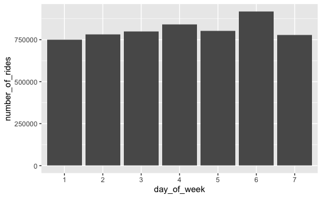

Week Day Transportation

```r
alltrips_v1 %>%
  group_by(day_of_week) %>%
  summarise(number_of_rides = n()) %>%
  ggplot(mapping = aes(x = day_of_week, y = number_of_rides)) + geom_col()
```

Data calculation on total number of rides on days of the week

```r
alltrips_v1 %>%
  group_by(day_of_week) %>%
  summarise(max(number_of_rides = n()))
```

[output not shown]

- The Plot and the statistical summary shows that most rides were on Saturday(916459).

Next, a plot of the ride_length or average_duration in minutes for every day of the week for members and casual riders is shown.

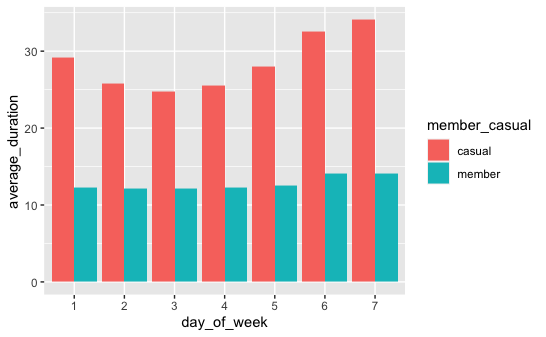

Ride Length

```r
alltrips_v1 %>%
  group_by(member_casual, day_of_week) %>%
  summarise(number_of_rides = n()
            ,average_duration = mean(ride_length_m)) %>%
  arrange(member_casual, day_of_week) %>%
  ggplot(aes(x = day_of_week, y = average_duration, fill = member_casual)) +
  geom_col(position = "dodge")
```

- The plot demonstrates that casual riders rent bikes for longer duration, especially on Saturday and Sunday. Members show a consistent riding rate riding/using behavior throughout the week.

Number of rides per day for every rider type is plotted.

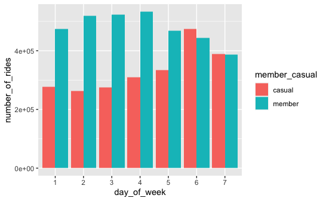

```r
alltrips_v1 %>%
  group_by(member_casual, day_of_week) %>%
  summarise(number_of_rides = n()
            ,average_duration = mean(ride_length_m)) %>%
  arrange(member_casual, day_of_week) %>%
  ggplot(aes(x = day_of_week, y = number_of_rides, fill = member_casual)) +
  geom_col(position = "dodge")
```

* Surprisingly, and in contrast to the former plot, members begin more rides and thus have higher number of rides on every day of the week except for Saturday and Sunday.

#### Second analysis step: average ride length depending on rider type and number of each rider type

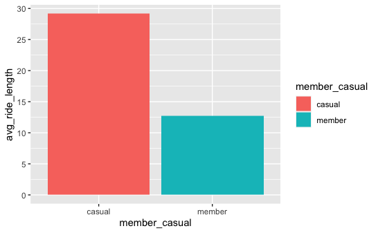

Average Ride Length

```r
alltrips_v1 %>%
  group_by(member_casual) %>%
  summarise(max(ride_length_m), min(ride_length_m), avg_ride_length = mean(ride_length_m)) %>%
  ggplot(aes(x = member_casual, y = avg_ride_length, fill=member_casual)) +
  geom_col()+ scale_y_continuous(breaks = seq(0, 40, by = 5))
```

```r
alltrips_v1 %>%
  group_by(member_casual) %>%
  summarise(max(ride_length_m), min(ride_length_m), avg_ride_length = mean(ride_length_m))
```

So, the result shows that casual riders tend to rent bikes for longer mean duration than members (29.1 min to 12.7 min), in accordance with plot 2. Members probably use bikes to commute, whereas casual riders maybe, among other things, exercising, visiting the city or attending special events.

Overall rider count based on rider type is plotted

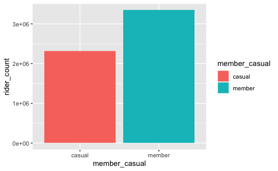

```r
alltrips_v1 %>%
  group_by(member_casual) %>%
  summarise(rider_count = n()) %>%
  ggplot(aes(x = member_casual, y = rider_count, fill=member_casual )) +
  geom_col()
```

* The plot indicates that more than half of all riders are member riders (3/(3+2.5)=0,55)

### Third analysis step: Exploring effect of seasonality

Here, the Function “season” of the library “metR” was used to assign season to months:

DJF:winter

MAM:Spring

JJA:Summer

SON:Fall

```r
alltrips_v1$season <- season(alltrips_v1$month)
```

Number of rides and ride length by weekday on each season.

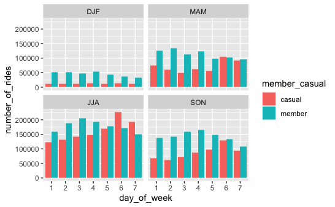

Week Day Rides By Seasons

```r
alltrips_v1 %>%
  group_by(season, day_of_week, member_casual) %>%
  summarise(number_of_rides =n()
  ,avg_ride_length = mean(ride_length_m)) %>%
  ggplot() + geom_col(mapping = aes(x = day_of_week, y = number_of_rides, fill = member_casual),
  position = "dodge") + facet_wrap(~season) + scale_y_continuous(breaks = seq(0, 400000, by = 50000))
```

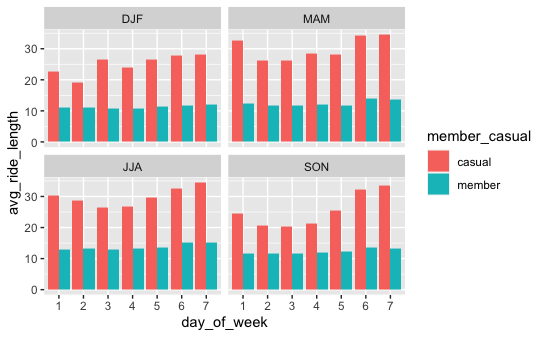

Ride Length By Seasons

```r
alltrips_v1 %>%
  group_by(season, day_of_week, member_casual) %>%
  summarise(number_of_rides =n()
  ,avg_ride_length = mean(ride_length_m)) %>%
  ggplot() + geom_col(mapping = aes(x = day_of_week, y = avg_ride_length, fill = member_casual),
  position = "dodge") + facet_wrap(~season) + scale_y_continuous(breaks = seq(0, 50, by = 10))
```

Line plot for continuous change of number of rides along the whole year for the two rider types.

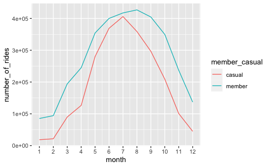

Rides In the Year

```r
alltrips_v1 %>%
  group_by(month, member_casual) %>%
  summarise(number_of_rides = n()
  ,avg_ride_length = mean(ride_length_m)) %>%
  ggplot() + geom_line(mapping = aes(x = month, y = number_of_rides, color = member_casual)) +
  scale_x_continuous(breaks = seq(1, 12, by = 1))
```

- The Plot shows that for casual and member riders, bike share peaks around Summer months and then hit a low point around Winter months.

### Share phase

#### Conclusions/Summary of insights

Members and casual riders differ in how long they use, how often they use the bikes, and on which days of the week does every group peak while using Cyclistic Bikes:

- Casual rides peak during weekends (plot3). There is a higher probability they are tourists visiting and sightseeing in the city, or they are your normal Chicago citizens who are riding bikes on their leisure time during the weekend. The longer average ride time for casual riders (plot2), also peaking at the weekend, provides evidence.
- Ride lengths for members are relatively shorter compared to casual riders. This could be clarified as such, most members use the bikes to commute on workdays. This clarification would also explain the short riding duration of members. They ride for necessity and usually the same ride lengths and the same distance.
- More than 50% of the riders are annual members (plots5), suggesting that the company has already achieved a good level of loyalty among its bike users. This indicates a positive message, namely that the company is going to convince many casual riders to become premium members, and keep their new members satisfied.

### Recommendations

Give discounts for longer rides when you have a membership Longer rides should fall under a type of rewards program when they become members